[figure not shown]

# About

This weekly workshop highlights the work of those pioneering data science analytical techniques and social science and computation methods while bringing together graduate students, post-docs, and faculty all working at the nexus of computation and big, social science questions. The workshop also allows regular participants to share works in progress for feedback, fosters robust dialogue between young scholars in these emerging fields, and showcases local scholars leading pedagogical seminars on new papers or methods.

**The 2018-2019 Computational Social Science Workshop meets each Thursday from *11 to 12:20 p.m.* in [Kent 120](https://maps.uchicago.edu/?location=Kent+Chemical+Laboratory)**. All interested faculty and graduate students are welcome. Our Computation MA students are expected to attend.

## [Winter 2019 Workshop Schedule](https://htmlpreview.github.io/?https://github.com/uchicago-computation-workshop/README/blob/master/Winter_2019_Schedule/winter_2019_schedule.html)

# Workshop Organizational Structure on Github

Each week of the Computational Social Science Workshop, we will add a new repository for that week’s speaker, paper, and discussion board contents. These repositories will each be hosted on the [Github page for the Computational Social Science Workshop](http://github.com/uchicago-computation-workshop). Each repository will have several recurring elements:

- Published or working version of the paper for the workshop talk
- Presentation from the workshop (if available post presentation)
- A README regarding the details of the talk, speaker, and location
- An Issues page, where MACSS students are expected to participate

# MACSS Participation and Open Source Debate

#### *Current MACSS students are expected to contribute to the **Issues** page for that week’s computation workshop*.

**Each week, *before the presentation***, you will do the following:

- Provide a thoughtful comment or question in response to the speaker’s paper
- React and comment on *at least* **5** other students’ comments

### The students questions with the most :thumbsup: reactions will have the opportunity to pose those questions to the speaker during the workshop.

### Suggestions for Posting Questions

This question could be methodological, theoretical, or substantive. For example, you might find an oversight in the analysis, question why a particular algorithm or model was run versus another, and so forth. In terms of theory, you might observe how the study claims to fill a gap in a particular subfield and cite papers of the particular perspective `X`, but wonder why they do not consider the counter theory `Y`. These might not necessarily be conceived as fissures in theoretical paradigms. You might have a simpler question about how the study relates to this recently published and related article in the `Journal of Z`.

Beyond critical observations or pointing to methodological, logical, or theoretical gaps, your comment might instead take the form of general questions regarding the scope of their data analysis, their strategy in compiling data or methodological toolkits, or what they feel would be new avenues of research.

**Note there are many possible questions you might ask but may already be answered** in the text, particularly if the work is published or near that stage. To this end, please read the papers carefully so that you may pose a question that recognizes the existing answers or gaps in the paper and builds on that body of work. Please do not ask questions or make pointed comments that reveal you have not actually read the paper closely, which will be apparent if your question is directly answered in the text.

At the same time, do not be afraid to ask questions for clarification about a complex argument, method, or point of confusion in the text. Experts may at times make too many leaps in their argument or discussion of a subject that may make sense to other experts but elude the otherwise intelligent. Asking for clarification can be useful since it may reveal a part of the paper, to which the author should better attend. If the paper confuses you, it may fluster a journal reviewer, and to avoid this possibility, the author will likely thank you for drawing their attention to the matter.

### Mechanics of Posting Questions

```python
def hello_world(name):
    print("Hello, {}. It is a beautiful world.".format(name))
```

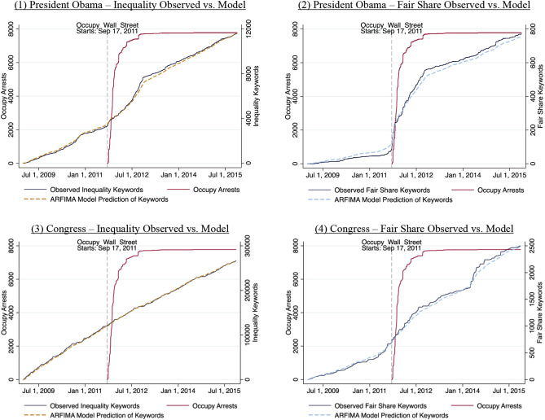

6. If you would like, you can reference another student’s question by tagging their issue number. Place `#X` in your post, where `X` is the number (1, 2, 3,…,N) associated with the post you would like to tag.

### Reacting to Questions

Beyond posing questions, students will be required to review and post reactions to each other’s questions. Each week students should react to and comment on the questions for at least 5 other students. Students whose questions garner the most :thumbsup: reactions, will have the opportunity to pose their question to the speaker during the workshop.

*Note:* You can add more than one reaction to a question, such as :thumbsup: or :heart:, however, we will only rank the number of reactions using the :thumbsup: reaction. For a full list of Github emoji’s see this page: https://gist.github.com/rxaviers/7360908.

Examples: An example issue and reaction set is available under my [example speaker repository](https://github.com/uchicago-computation-workshop/joshua_mausolf/issues). Besides the use for discussion in this workshop, issues pages are also used to raise questions, requests, or problems in code used in professional development, by companies such as [Spotify](https://github.com/spotify/luigi/issues/1622) or [Facebook](https://github.com/facebook/flow/issues/396).